# Intertwining of the Igf system and animal welfare

# IGFBP2/IGFBP3 (serum)

## Model

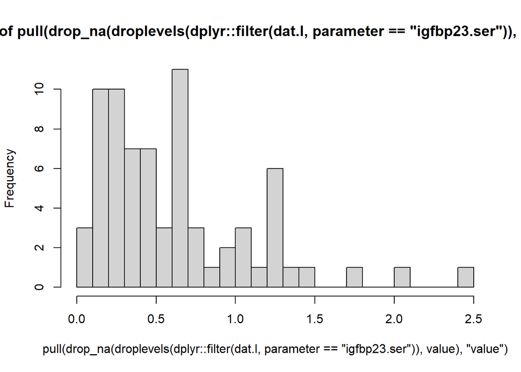

```r
hist(dat.l |>
       dplyr::filter(parameter == "igfbp23.ser") |>
       droplevels() |>
       drop_na(value) |>
       pull("value"),
     breaks = 30)
```

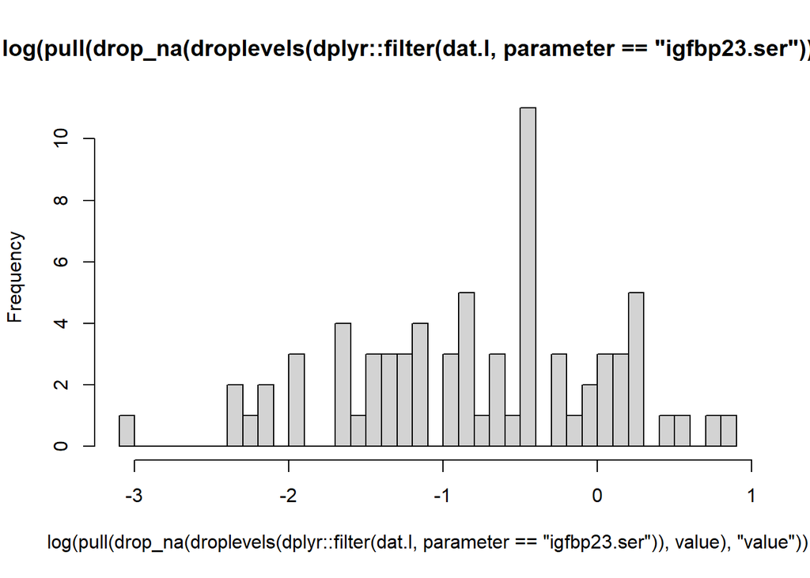

```r
hist(log(dat.l |>
         dplyr::filter(parameter == "igfbp23.ser") |>
         droplevels() |>
         drop_na(value) |>
         pull("value")),
     breaks = 30)
```

Singularity issues if nested structure defined like `(1 | sow/litter.no)`.

```r
mod.igfbp23 <- lmerTest::lmer(log(value) ~
                               husbandry +
                               time +
                               # interaction term
                               husbandry : time +
                               # random intercept for sows and for each litter within sow
                               (1 | sow/litter.no),
                             data    = dat.l |>
                               dplyr::filter(parameter == "igfbp23.ser") |>
                               droplevels() |>
                               drop_na(value),
                             REML    = TRUE,
                             control = contr)
```

```
boundary (singular) fit: see help('isSingular')
```

```r
summary(mod.igfbp23)
```

```
Linear mixed model fit by REML. t-tests use Satterthwaite's method [
lmerModLmerTest]
Formula: log(value) ~ husbandry + time + husbandry:time + (1 | sow/litter.no)
   Data: drop_na(droplevels(dplyr::filter(dat.l, parameter == "igfbp23.ser")),
    value)
Control: contr

REML criterion at convergence: 144.5

Scaled residuals:
     Min       1Q   Median       3Q      Max
-1.97572 -0.51849 -0.00712  0.49478  1.73489

Random effects:
 Groups        Name        Variance Std.Dev.
 litter.no:sow (Intercept) 0.4515   0.6719
 sow           (Intercept) 0.0000   0.0000
 Residual                  0.1608   0.4010
Number of obs: 72, groups:  litter.no:sow, 36; sow, 15

Fixed effects:
                             Estimate Std. Error      df t value Pr(>|t|)
(Intercept)                   -0.2861     0.1844 44.0488  -1.551 0.127980
husbandryecological           -0.5229     0.2608 44.0488  -2.005 0.051155 .
time8dpp                      -0.5724     0.1337 34.0000  -4.282 0.000143 ***
husbandryecological:time8dpp   0.1733     0.1890 34.0000   0.917 0.365645
---
Signif. codes:  0 '***' 0.001 '**' 0.01 '*' 0.05 '.' 0.1 ' ' 1

Correlation of Fixed Effects:
            (Intr) hsbndr tm8dpp
hsbndryclgc -0.707
time8dpp    -0.362  0.256
hsbndrycl:8  0.256 -0.362 -0.707
optimizer (bobyqa) convergence code: 0 (OK)
boundary (singular) fit: see help('isSingular')
```

```r
round(drop1(mod.igfbp23, test = 'Chisq'), 3)
```

```
Single term deletions using Satterthwaite's method:

Model:
log(value) ~ husbandry + time + husbandry:time + (1 | sow/litter.no)
               Sum Sq Mean Sq NumDF DenDF F value Pr(>F)
husbandry:time  0.135   0.135     1    34   0.841  0.366
```

Without significant interactions, choose `type = 2`. With significant interactions, choose `type = 3`.

```r
car::Anova(mod.igfbp23,
           test.statistic = "Chisq",
           type = 2)
```

```
Analysis of Deviance Table (Type II Wald chisquare tests)

Response: log(value)
                 Chisq Df Pr(>Chisq)
husbandry       3.2202  1    0.07273 .
time           26.4099  1  2.761e-07 ***
husbandry:time  0.8407  1    0.35919
---
Signif. codes:  0 '***' 0.001 '**' 0.01 '*' 0.05 '.' 0.1 ' ' 1
```

```r
car::Anova(mod.igfbp23,
           test.statistic = "F",
           type = 2)
```

```
Analysis of Deviance Table (Type II Wald F tests with Kenward-Roger df)

Response: log(value)
                     F Df Df.res    Pr(>F)
husbandry       3.1232  1 10.995    0.1049
time           26.4099  1 34.000 1.134e-05 ***
husbandry:time  0.8407  1 34.000    0.3656
---
Signif. codes:  0 '***' 0.001 '**' 0.01 '*' 0.05 '.' 0.1 ' ' 1
```

## Model diagnostics

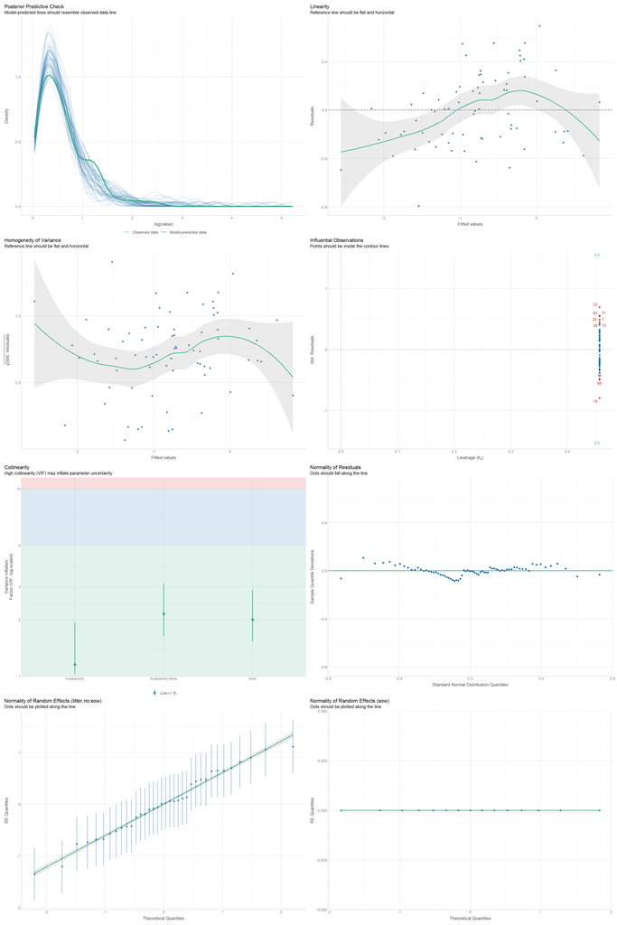

```r
performance::check_model(mod.igfbp23)
```

## Emmeans & Effect sizes

### Husbandry

Emmeans:

```r
emm <- emmeans(mod.igfbp23,
        pairwise ~ husbandry,
        data    = dat.l |>
          dplyr::filter(parameter == "igfbp23.ser") |>
          droplevels() |>
          drop_na(value),
        adjust  = "tukey",
        lmer.df = "satterthwaite",
        type    = "response")
```

```
NOTE: Results may be misleading due to involvement in interactions
```

```r
emm
```

```
$emmeans
 husbandry    response     SE df lower.CL upper.CL
 conventional    0.564 0.0970 34    0.398    0.800
 ecological      0.365 0.0627 34    0.257    0.517

Results are averaged over the levels of: time
Degrees-of-freedom method: satterthwaite
Confidence level used: 0.95
Intervals are back-transformed from the log scale

$contrasts
 contrast                  ratio    SE df null t.ratio p.value
 conventional / ecological  1.55 0.376 34    1   1.795  0.0816

Results are averaged over the levels of: time
Degrees-of-freedom method: satterthwaite
Tests are performed on the log scale
```

Effect sizes:

```r
eff_size(emm,
         sigma = sigma(mod.igfbp23),
         edf = df.residual(mod.igfbp23))
```

```
Since 'object' is a list, we are using the contrasts already present.
```

```
 contrast                    estimate    SE df lower.CL upper.CL
 (conventional - ecological)     1.09 0.614 34   -0.159     2.34

Results are averaged over the levels of: time
sigma used for effect sizes: 0.401
Degrees-of-freedom method: inherited from satterthwaite when re-gridding
Confidence level used: 0.95
```

### Time point

Emmeans:

```r
emm <- emmeans(mod.igfbp23,
        pairwise ~ time,
        data    = dat.l |>
          dplyr::filter(parameter == "igfbp23.ser") |>
          droplevels() |>
          drop_na(value),
        adjust  = "tukey",
        lmer.df = "satterthwaite",
        type    = "response")
```

```
NOTE: Results may be misleading due to involvement in interactions
```

```r
emm
```

```
$emmeans
 time   response     SE df lower.CL upper.CL
 105dpc    0.578 0.0754 44    0.445    0.752
 8dpp      0.356 0.0464 44    0.274    0.463

Results are averaged over the levels of: husbandry
Degrees-of-freedom method: satterthwaite
Confidence level used: 0.95
Intervals are back-transformed from the log scale

$contrasts
 contrast      ratio    SE df null t.ratio p.value
 105dpc / 8dpp  1.63 0.154 34    1   5.139  <.0001

Results are averaged over the levels of: husbandry
Degrees-of-freedom method: satterthwaite
Tests are performed on the log scale
```

Effect sizes:

```r
eff_size(emm,
         sigma = sigma(mod.igfbp23),
         edf = df.residual(mod.igfbp23))
```

```
Since 'object' is a list, we are using the contrasts already present.
```

```
 contrast        estimate    SE df lower.CL upper.CL
 (105dpc - 8dpp)     1.21 0.259 34    0.686     1.74

Results are averaged over the levels of: husbandry
sigma used for effect sizes: 0.401
Degrees-of-freedom method: inherited from satterthwaite when re-gridding
Confidence level used: 0.95
```

### Husbandry:Time point

Emmeans:

```r
emm.igfbp23_ht <- emmeans(mod.igfbp23,
                          pairwise ~ husbandry|time,
                          data    = dat.l |>
                            dplyr::filter(parameter == "igfbp23.ser") |>
                            droplevels() |>
                            drop_na(value),
                          adjust  = "tukey",
                          lmer.df = "satterthwaite",
                          type    = "response")

emm.igfbp23_ht
```

```
$emmeans
time = 105dpc:
 husbandry    response     SE df lower.CL upper.CL
 conventional    0.751 0.1390 44    0.518    1.089
 ecological      0.445 0.0821 44    0.307    0.646

time = 8dpp:
 husbandry    response     SE df lower.CL upper.CL
 conventional    0.424 0.0782 44    0.292    0.615
 ecological      0.299 0.0551 44    0.206    0.433

Degrees-of-freedom method: satterthwaite
Confidence level used: 0.95
Intervals are back-transformed from the log scale

$contrasts
time = 105dpc:
 contrast                  ratio   SE df null t.ratio p.value
 conventional / ecological  1.69 0.44 44    1   2.005  0.0512

time = 8dpp:
 contrast                  ratio   SE df null t.ratio p.value
 conventional / ecological  1.42 0.37 44    1   1.340  0.1870

Degrees-of-freedom method: satterthwaite
Tests are performed on the log scale
```

Effect sizes:

```r
eff_size(emm.igfbp23_ht,
         sigma = sigma(mod.igfbp23),
         edf = df.residual(mod.igfbp23))
```

```
Since 'object' is a list, we are using the contrasts already present.
```

```
time = 105dpc:
 contrast                    estimate    SE df lower.CL upper.CL
 (conventional - ecological)    1.304 0.660 44  -0.0269     2.64

time = 8dpp:
 contrast                    estimate    SE df lower.CL upper.CL
 (conventional - ecological)    0.872 0.655 44  -0.4481     2.19

sigma used for effect sizes: 0.401
Degrees-of-freedom method: inherited from satterthwaite when re-gridding
Confidence level used: 0.95
```

### Time point:Husbandry

Emmeans:

```r
emm.igfbp23_th <- emmeans(mod.igfbp23,
                          pairwise ~ time|husbandry,
                          data    = dat.l |>
                            dplyr::filter(parameter == "igfbp23.ser") |>
                            droplevels() |>
                            drop_na(value),
                          adjust  = "tukey",
                          lmer.df = "satterthwaite",
                          type    = "response")

emm.igfbp23_th
```

```
$emmeans
husbandry = conventional:
 time   response     SE df lower.CL upper.CL
 105dpc    0.751 0.1390 44    0.518    1.089
 8dpp      0.424 0.0782 44    0.292    0.615

husbandry = ecological:
 time   response     SE df lower.CL upper.CL
 105dpc    0.445 0.0821 44    0.307    0.646
 8dpp      0.299 0.0551 44    0.206    0.433

Degrees-of-freedom method: satterthwaite
Confidence level used: 0.95
Intervals are back-transformed from the log scale

$contrasts
husbandry = conventional:
 contrast      ratio    SE df null t.ratio p.value
 105dpc / 8dpp  1.77 0.237 34    1   4.282  0.0001

husbandry = ecological:
 contrast      ratio    SE df null t.ratio p.value
 105dpc / 8dpp  1.49 0.199 34    1   2.986  0.0052

Degrees-of-freedom method: satterthwaite
Tests are performed on the log scale
```

Effect sizes:

```r
eff_size(emm.igfbp23_th,
         sigma = sigma(mod.igfbp23),
         edf = df.residual(mod.igfbp23))
```

```
Since 'object' is a list, we are using the contrasts already present.
```

```
husbandry = conventional:
 contrast        estimate    SE df lower.CL upper.CL
 (105dpc - 8dpp)    1.427 0.356 34    0.704     2.15

husbandry = ecological:
 contrast        estimate    SE df lower.CL upper.CL
 (105dpc - 8dpp)    0.995 0.345 34    0.295     1.70

sigma used for effect sizes: 0.401
Degrees-of-freedom method: inherited from satterthwaite when re-gridding
Confidence level used: 0.95
```

## Plot

Add significant contrasts to the plot:

```r
contr.igfbp23_th <- contrast(emm.igfbp23_th, method = "pairwise") |>
  as.data.frame() |>
  as_tibble() |>
  mutate(p.label = dplyr::case_when(
    p.value < 0.001 ~ "p < 0.001",
    p.value < 0.05  ~ sprintf("p = %.3f", p.value),
    TRUE            ~ NA_character_)) |>
  # for brackets
  mutate(
    group1 = "105dpc",
    group2 = "8dpp") |>
  mutate(
    xmin = case_when(
      husbandry == "conventional" ~ 0.875,
      husbandry == "ecological"   ~ 1.125
    ),
    xmax = case_when(
      husbandry == "conventional" ~ 1.875,
      husbandry == "ecological"   ~ 2.125)) |>
  mutate(y.position = 2.3) |>
  # only significant results
  dplyr::filter(!is.na(p.label))
```

```r
plot.igfbp23 <- dat.l  |>
  dplyr::filter(parameter == "igfbp23.ser") |>
  droplevels() |>
  drop_na(value) |>
  # plot
  mutate(jit = jitter(as.numeric(time), 0.3)) |>
  ggplot(aes(y   = (value))) +
  geom_boxplot(aes(x   = time,
                   fill = husbandry),
               col = "black",
               outlier.shape = NA, width = 0.5) +
  geom_jitter(aes(x   = time,
                  fill = husbandry),
              col = "black",
              position = position_jitterdodge(jitter.width  = 0.15,
                                              dodge.width   = 0.5),
              size = 2, alpha = 0.7,
              show.legend = FALSE) +
  ggpubr::stat_pvalue_manual(
    contr.igfbp23_th,
    inherit.aes = FALSE,
    label = "p.label",
    xmin = "xmin",
    xmax = "xmax",
    y.position = "y.position",
    step.increase = 0.1,
    size = 14/.pt,
    bracket.size = 0.8,
    tip.length = 0.03,
    position = position_dodge(width = 0.5)) +
  scale_fill_manual(labels = c("Conventional",
                               "Ecological"),
                    values = c("#FFA040", "#008000")) +
  scale_y_continuous(breaks = seq(0, 2.5, 0.5),
                     minor_breaks = seq(0, 2.5, by = 0.1),
                     expand = expansion(mult = c(0.05, 0.1))) +
  # important to define limits of the coord system not of the y-axis
  coord_cartesian(ylim = c(0, 2.5), clip = "off") +
  scale_x_discrete(labels= c("105dpc", "8dpp")) +
  labs(x = "",
       y = "Molar ratio of IGFBP2/IGFBP3 (serum)",
       fill = "Husbandry") +
  my_theme +
  theme(legend.position = "top") +
  guides(y = guide_axis(minor.ticks = TRUE),
         fill = guide_legend(override.aes = list(linetype = 0, size  = 5)))
```

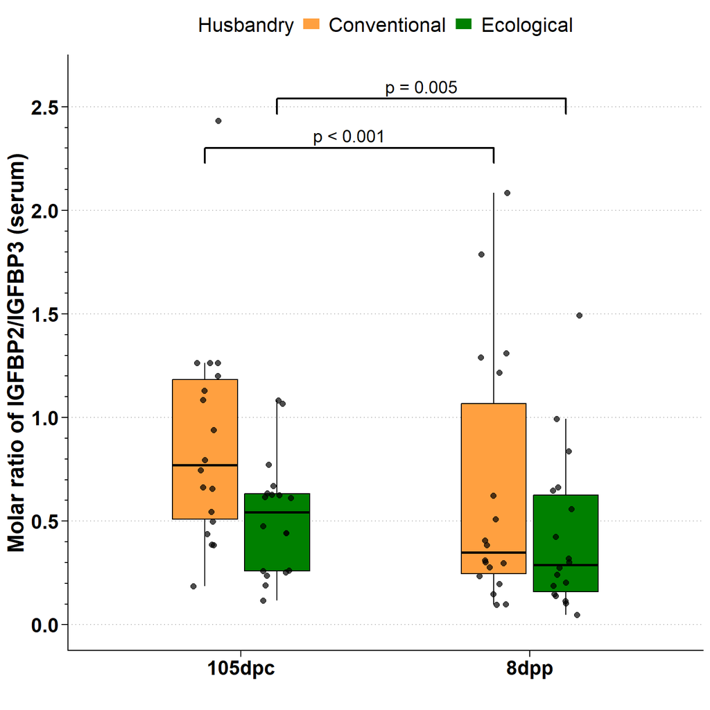

```r
plot.igfbp23
```

# Stanniocalcin, STC1 (serum)

## Model

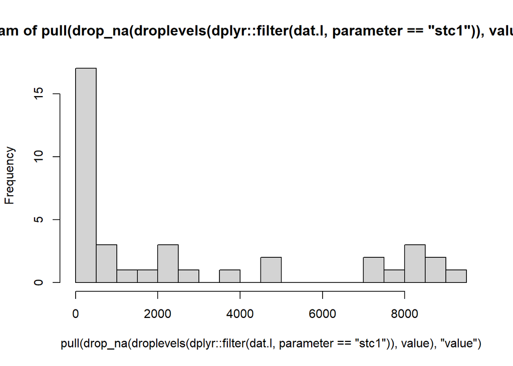

```r
hist(dat.l |>
       dplyr::filter(parameter == "stc1") |>
       droplevels() |>
       drop_na(value) |>
       pull("value"),
     breaks = 30)
```

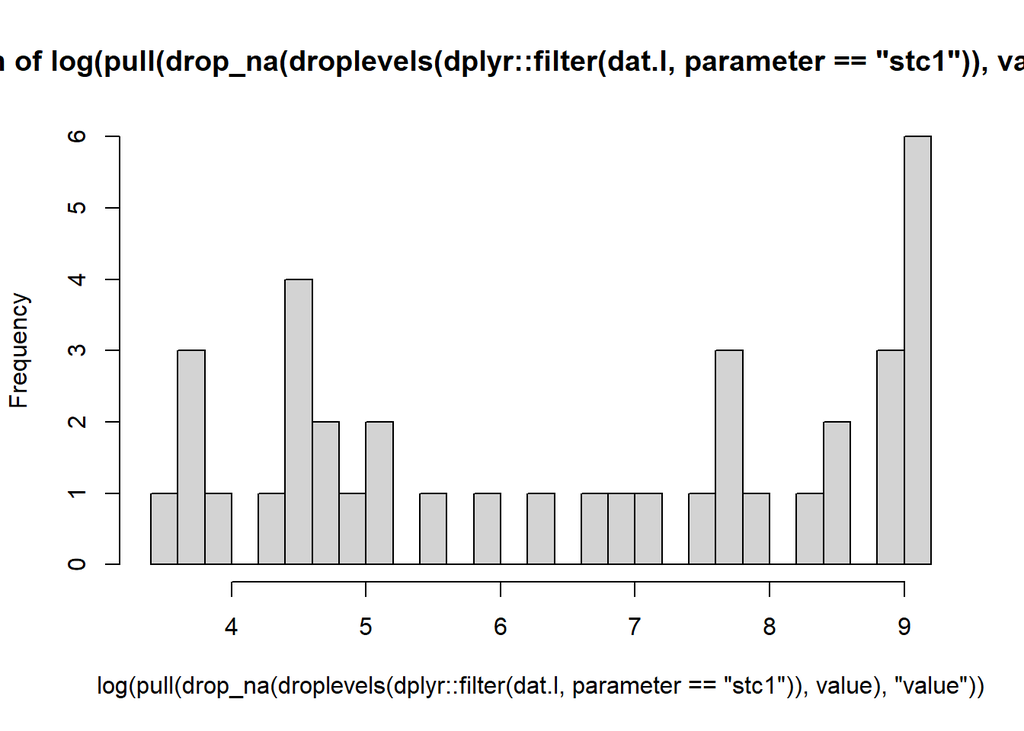

```r
hist(log(dat.l |>
         dplyr::filter(parameter == "stc1") |>
         droplevels() |>
         drop_na(value) |>
         pull("value")),
     breaks = 30)
```

Singularity issues if nested structure defined like `(1 | sow/litter.no)`.

```r
mod.stc1 <- lmerTest::lmer(log(value) ~
                               husbandry +
                               time +
                               # interaction term
                               husbandry : time +
                               # random intercept for sows and for each litter within sow
                               (1 | sow/litter.no),
                             data    = dat.l |>
                               dplyr::filter(parameter == "stc1") |>
                               droplevels() |>
                               drop_na(value),
                             REML    = TRUE,
                             control = contr)
```

```
boundary (singular) fit: see help('isSingular')
```

```r
summary(mod.stc1)
```

```
Linear mixed model fit by REML. t-tests use Satterthwaite's method [
lmerModLmerTest]
Formula: log(value) ~ husbandry + time + husbandry:time + (1 | sow/litter.no)
   Data: drop_na(droplevels(dplyr::filter(dat.l, parameter == "stc1")),
    value)
Control: contr

REML criterion at convergence: 88.2

Scaled residuals:
     Min       1Q   Median       3Q      Max
-1.58308 -0.48078  0.00956  0.47032  1.39341

Random effects:
 Groups        Name        Variance Std.Dev.
 litter.no:sow (Intercept) 3.17571  1.7821
 sow           (Intercept) 0.00000  0.0000
 Residual                  0.05628  0.2372
Number of obs: 38, groups:  litter.no:sow, 19; sow, 14

Fixed effects:
                             Estimate Std. Error       df t value Pr(>|t|)
(Intercept)                   5.62613    0.59926 17.29863   9.388 3.32e-08 ***
husbandryecological           1.99293    0.82602 17.29863   2.413   0.0272 *
time8dpp                     -0.31643    0.11184 17.00000  -2.829   0.0116 *
husbandryecological:time8dpp  0.08471    0.15416 17.00000   0.550   0.5898
---
Signif. codes:  0 '***' 0.001 '**' 0.01 '*' 0.05 '.' 0.1 ' ' 1

Correlation of Fixed Effects:
            (Intr) hsbndr tm8dpp
hsbndryclgc -0.725
time8dpp    -0.093  0.068
hsbndrycl:8  0.068 -0.093 -0.725
optimizer (bobyqa) convergence code: 0 (OK)
boundary (singular) fit: see help('isSingular')
```

```r
round(drop1(mod.stc1, test = 'Chisq'), 3)
```

```
Single term deletions using Satterthwaite's method:

Model:
log(value) ~ husbandry + time + husbandry:time + (1 | sow/litter.no)
               Sum Sq Mean Sq NumDF DenDF F value Pr(>F)
husbandry:time  0.017   0.017     1    17   0.302   0.59
```

Without significant interactions, choose `type = 2`. With significant interactions, choose `type = 3`.

```r
car::Anova(mod.stc1,
           test.statistic = "Chisq",
           type = 2)
```

```
Analysis of Deviance Table (Type II Wald chisquare tests)

Response: log(value)
                 Chisq Df Pr(>Chisq)
husbandry       6.1244  1  0.0133326 *
time           12.4733  1  0.0004128 ***
husbandry:time  0.3020  1  0.5826404
---
Signif. codes:  0 '***' 0.001 '**' 0.01 '*' 0.05 '.' 0.1 ' ' 1
```

```r
car::Anova(mod.stc1,
           test.statistic = "F",
           type = 2)
```

```
Analysis of Deviance Table (Type II Wald F tests with Kenward-Roger df)

Response: log(value)
                     F Df Df.res   Pr(>F)
husbandry       5.4881  1 10.123 0.040863 *
time           12.4733  1 17.000 0.002561 **
husbandry:time  0.3020  1 17.000 0.589787
---
Signif. codes:  0 '***' 0.001 '**' 0.01 '*' 0.05 '.' 0.1 ' ' 1
```

## Model diagnostics

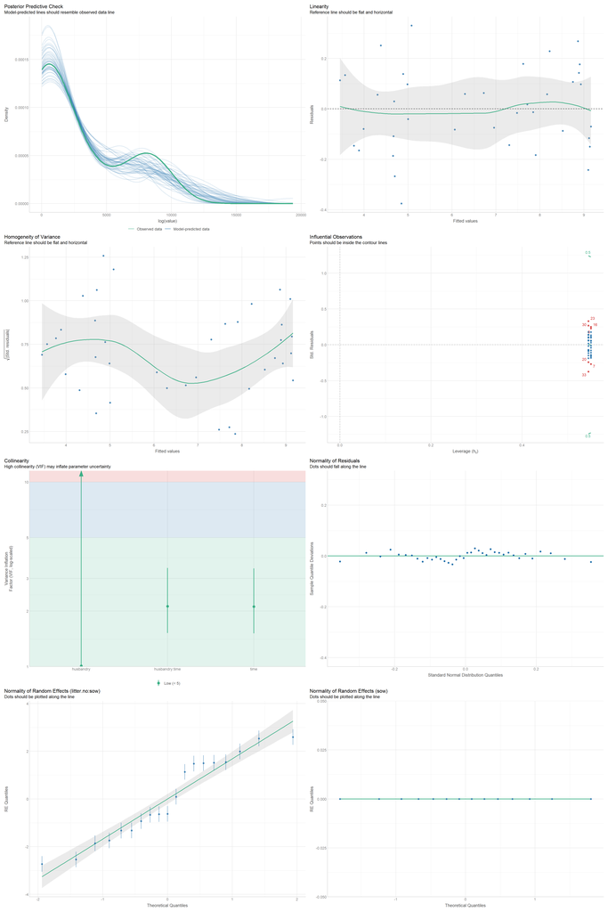

```r
performance::check_model(mod.stc1)
```

## Emmeans & Effect sizes

### Husbandry

Emmeans:

```r
emm <- emmeans(mod.stc1,
        pairwise ~ husbandry,
        data    = dat.l |>
          dplyr::filter(parameter == "stc1") |>
          droplevels() |>
          drop_na(value),
        adjust  = "tukey",
        lmer.df = "satterthwaite",
        type    = "response")
```

```
NOTE: Results may be misleading due to involvement in interactions
```

```r
emm
```

```
$emmeans
 husbandry    response   SE df lower.CL upper.CL
 conventional      237  141 17     67.3      834
 ecological       1814 1030 17    549.5     5987

Results are averaged over the levels of: time
Degrees-of-freedom method: satterthwaite
Confidence level used: 0.95
Intervals are back-transformed from the log scale

$contrasts
 contrast                  ratio    SE df null t.ratio p.value
 conventional / ecological 0.131 0.107 17    1  -2.475  0.0242

Results are averaged over the levels of: time
Degrees-of-freedom method: satterthwaite
Tests are performed on the log scale
```

Effect sizes:

```r
eff_size(emm,
         sigma = sigma(mod.stc1),
         edf = df.residual(mod.stc1))
```

```
Since 'object' is a list, we are using the contrasts already present.
```

```
 contrast                    estimate   SE df lower.CL upper.CL
 (conventional - ecological)    -8.58 3.63 17    -16.2   -0.912

Results are averaged over the levels of: time
sigma used for effect sizes: 0.2372
Degrees-of-freedom method: inherited from satterthwaite when re-gridding
Confidence level used: 0.95
```

### Time point

Emmeans:

```r
emm <- emmeans(mod.stc1,
        pairwise ~ time,
        data    = dat.l |>
          dplyr::filter(parameter == "stc1") |>
          droplevels() |>
          drop_na(value),
        adjust  = "tukey",
        lmer.df = "satterthwaite",
        type    = "response")
```

```
NOTE: Results may be misleading due to involvement in interactions
```

```r
emm
```

```
$emmeans
 time   response  SE   df lower.CL upper.CL
 105dpc      752 311 17.3      315     1795
 8dpp        572 236 17.3      239     1365

Results are averaged over the levels of: husbandry
Degrees-of-freedom method: satterthwaite
Confidence level used: 0.95
Intervals are back-transformed from the log scale

$contrasts
 contrast      ratio    SE df null t.ratio p.value
 105dpc / 8dpp  1.32 0.101 17    1   3.556  0.0024

Results are averaged over the levels of: husbandry
Degrees-of-freedom method: satterthwaite
Tests are performed on the log scale
```

Effect sizes:

```r
eff_size(emm,
         sigma = sigma(mod.stc1),
         edf = df.residual(mod.stc1))
```

```
Since 'object' is a list, we are using the contrasts already present.
```

```
 contrast        estimate    SE df lower.CL upper.CL
 (105dpc - 8dpp)     1.16 0.356 17    0.403     1.91

Results are averaged over the levels of: husbandry
sigma used for effect sizes: 0.2372
Degrees-of-freedom method: inherited from satterthwaite when re-gridding
Confidence level used: 0.95
```

### Husbandry:Time point

Emmeans:

```r
emm.stc1_ht <- emmeans(mod.stc1,
                       pairwise ~ husbandry|time,
                       data    = dat.l |>
                         dplyr::filter(parameter == "stc1") |>
                         droplevels() |>
                         drop_na(value),
                       adjust  = "tukey",
                       lmer.df = "satterthwaite",
                       type    = "response")

emm.stc1_ht
```

```
$emmeans
time = 105dpc:
 husbandry    response   SE   df lower.CL upper.CL
 conventional      278  166 17.3     78.5      981
 ecological       2037 1160 17.3    614.7     6747

time = 8dpp:
 husbandry    response   SE   df lower.CL upper.CL
 conventional      202  121 17.3     57.2      715
 ecological       1615  918 17.3    487.6     5352

Degrees-of-freedom method: satterthwaite
Confidence level used: 0.95
Intervals are back-transformed from the log scale

$contrasts
time = 105dpc:
 contrast                  ratio    SE   df null t.ratio p.value
 conventional / ecological 0.136 0.113 17.3    1  -2.413  0.0272

time = 8dpp:
 contrast                  ratio    SE   df null t.ratio p.value
 conventional / ecological 0.125 0.103 17.3    1  -2.515  0.0220

Degrees-of-freedom method: satterthwaite
Tests are performed on the log scale
```

Effect sizes:

```r
eff_size(emm.stc1_ht,
         sigma = sigma(mod.stc1),
         edf = df.residual(mod.stc1))
```

```
Since 'object' is a list, we are using the contrasts already present.
```

```
time = 105dpc:
 contrast                    estimate   SE   df lower.CL upper.CL
 (conventional - ecological)    -8.40 3.64 17.3    -16.1   -0.727

time = 8dpp:
 contrast                    estimate   SE   df lower.CL upper.CL
 (conventional - ecological)    -8.76 3.66 17.3    -16.5   -1.056

sigma used for effect sizes: 0.2372
Degrees-of-freedom method: inherited from satterthwaite when re-gridding
Confidence level used: 0.95
```

### Time point:Husbandry

Emmeans:

```r
emm.stc1_th <- emmeans(mod.stc1,
                       pairwise ~ time|husbandry,
                       data    = dat.l |>
                         dplyr::filter(parameter == "stc1") |>
                         droplevels() |>
                         drop_na(value),
                       adjust  = "tukey",
                       lmer.df = "satterthwaite",
                       type    = "response")

emm.stc1_th
```

```
$emmeans
husbandry = conventional:
 time   response   SE   df lower.CL upper.CL
 105dpc      278  166 17.3     78.5      981
 8dpp        202  121 17.3     57.2      715

husbandry = ecological:
 time   response   SE   df lower.CL upper.CL
 105dpc     2037 1160 17.3    614.7     6747
 8dpp       1615  918 17.3    487.6     5352

Degrees-of-freedom method: satterthwaite
Confidence level used: 0.95
Intervals are back-transformed from the log scale

$contrasts
husbandry = conventional:
 contrast      ratio    SE df null t.ratio p.value
 105dpc / 8dpp  1.37 0.153 17    1   2.829  0.0116

husbandry = ecological:
 contrast      ratio    SE df null t.ratio p.value
 105dpc / 8dpp  1.26 0.134 17    1   2.184  0.0433

Degrees-of-freedom method: satterthwaite
Tests are performed on the log scale
```

Effect sizes:

```r
eff_size(emm.stc1_th,
         sigma = sigma(mod.stc1),
         edf = df.residual(mod.stc1))
```

```
Since 'object' is a list, we are using the contrasts already present.
```

```
husbandry = conventional:
 contrast        estimate    SE df lower.CL upper.CL
 (105dpc - 8dpp)    1.334 0.501 17  0.27695     2.39

husbandry = ecological:
 contrast        estimate    SE df lower.CL upper.CL
 (105dpc - 8dpp)    0.977 0.464 17 -0.00245     1.96

sigma used for effect sizes: 0.2372
Degrees-of-freedom method: inherited from satterthwaite when re-gridding
Confidence level used: 0.95
```

## Plot

Add significant contrasts to the plot:

```r
contr.stc1_ht <- contrast(emm.stc1_ht, method = "pairwise") |>
  as.data.frame() |>
  as_tibble() |>
  mutate(p.label = dplyr::case_when(
    p.value < 0.001 ~ "p < 0.001",
    p.value < 0.05  ~ sprintf("p = %.3f", p.value),
    TRUE            ~ NA_character_)) |>
  # for brackets
  mutate(
    group1 = "conventional",
    group2 = "ecological") |>
  mutate(
    x = as.numeric(time),
    xmin = x - 0.25 * 0.5,
    xmax = x + 0.25 * 0.5) |>
  mutate(y.position = 9000) |>
  # only significant results
  dplyr::filter(!is.na(p.label))
```

```r
contr.stc1_th <- contrast(emm.stc1_th, method = "pairwise") |>
  as.data.frame() |>
  as_tibble() |>
  mutate(p.label = dplyr::case_when(
    p.value < 0.001 ~ "p < 0.001",
    p.value < 0.05  ~ sprintf("p = %.3f", p.value),
    TRUE            ~ NA_character_)) |>
  # for brackets
  mutate(
    group1 = "105dpc",
    group2 = "8dpp") |>
  mutate(
    xmin = case_when(
      husbandry == "conventional" ~ 0.875,
      husbandry == "ecological"   ~ 1.125
    ),
    xmax = case_when(
      husbandry == "conventional" ~ 1.875,
      husbandry == "ecological"   ~ 2.125)) |>
  mutate(y.position = 10000) |>
  # only significant results
  dplyr::filter(!is.na(p.label))
```

```r
plot.stc1 <- dat.l  |>
  dplyr::filter(parameter == "stc1") |>
  droplevels() |>
  drop_na(value) |>
  # plot
  mutate(jit = jitter(as.numeric(time), 0.3)) |>
  ggplot(aes(y   = value)) +
  geom_boxplot(aes(x   = time,
                   fill = husbandry),
               col = "black",
               outlier.shape = NA, width = 0.5) +
  geom_jitter(aes(x   = time,
                  fill = husbandry),
              col = "black",
              position = position_jitterdodge(jitter.width  = 0.15,
                                              dodge.width   = 0.5),
              size = 2, alpha = 0.7,
              show.legend = FALSE) +
  ggpubr::stat_pvalue_manual(
    contr.stc1_ht,
    inherit.aes = FALSE,
    label = "p.label",
    xmin = "xmin",
    xmax = "xmax",
    y.position = "y.position",
    size = 14/.pt,
    bracket.size = 0.8,
    tip.length = 0.03,
    position = position_dodge(width = 0.5)) +
  ggpubr::stat_pvalue_manual(
    contr.stc1_th,
    inherit.aes = FALSE,
    label = "p.label",
    xmin = "xmin",
    xmax = "xmax",
    y.position = "y.position",
    step.increase = 0.1,
    size = 14/.pt,
    bracket.size = 0.8,
    tip.length = 0.03,
    position = position_dodge(width = 0.5)) +
  scale_fill_manual(labels = c("Conventional",
                               "Ecological"),
                    values = c("#FFA040", "#008000")) +
  scale_y_continuous(breaks = seq(0, 10000, 2000),
                     minor_breaks = seq(0, 10000, by = 400),
                     expand = expansion(mult = c(0.05, 0.1))) +
  # important to define limits of the coord system not of the y-axis
  coord_cartesian(ylim = c(0, 10000), clip = "off") +
  scale_x_discrete(labels= c("105dpc", "8dpp")) +
  labs(x = "",
       y = "STC1 (serum) [pg/ml]",
       fill = "Husbandry") +
  my_theme +
  theme(legend.position = "top") +
  guides(y = guide_axis(minor.ticks = TRUE),
         fill = guide_legend(override.aes = list(linetype = 0, size  = 5)))
```

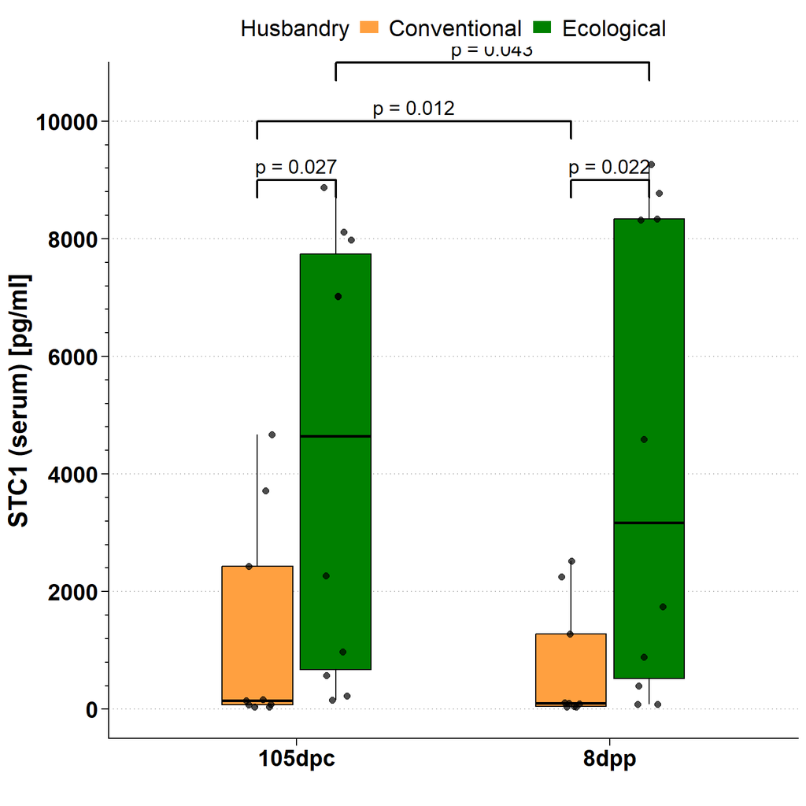

```r
plot.stc1
```

# Combined plots: Figure 5

```r
# Combine plots with a designated area for the legend
combined <- (plot.igfbp23 +
             plot.stc1) +
  plot_annotation(tag_levels = 'A') &
  theme(plot.tag = element_text(face = "bold", size = 20),
        legend.position = "bottom")
```

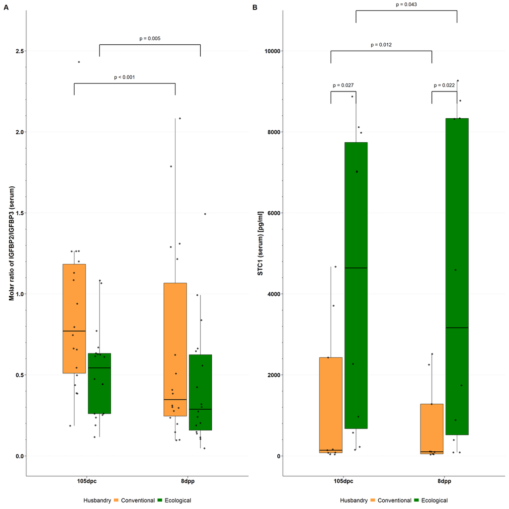

```r
combined
```

```r
png("./plots/figure5.png",
     width = 300, height = 200, units = "mm",
     pointsize = 10, res = 600)

combined
dev.off()
```

# Proteolytic activity (serum)

## Model

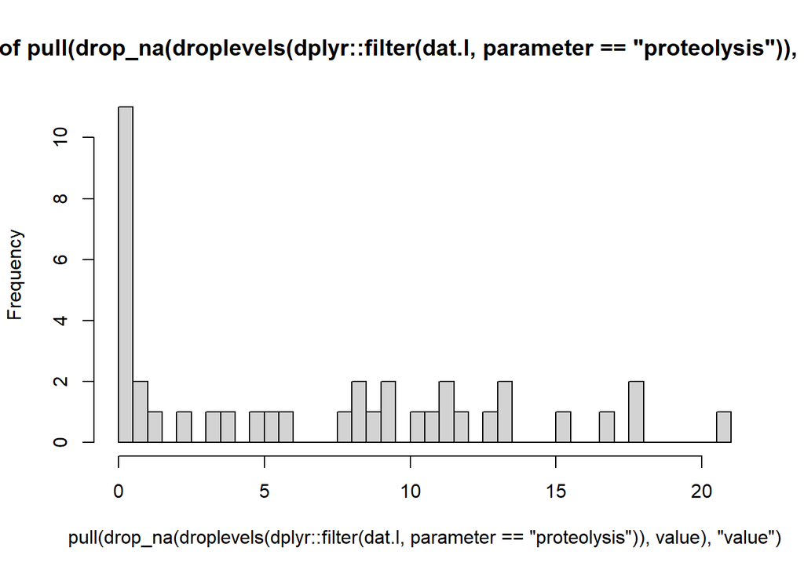

```r
hist(dat.l |>
       dplyr::filter(parameter == "proteolysis") |>
       droplevels() |>
       drop_na(value) |>
       pull("value"),
     breaks = 30)
```

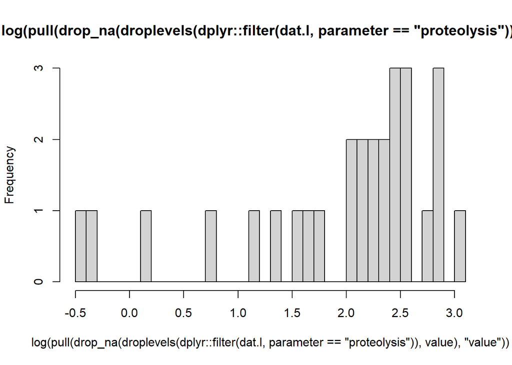

```r
hist(log(dat.l |>
         dplyr::filter(parameter == "proteolysis") |>
         droplevels() |>
         drop_na(value) |>
         pull("value")),
     breaks = 30)
```

Singularity issues if nested structure defined like `(1 | sow/litter.no)`.

```r
mod.prot <- lmerTest::lmer(log(value+1) ~
                               husbandry +
                               time +
                               # interaction term
                               husbandry : time +
                               # random intercept for sows and for each litter within sow
                               (1 | sow/litter.no),
                             data    = dat.l |>
                              dplyr::filter(parameter == "proteolysis") |>
                              droplevels() |>
                              drop_na(value),
                             REML    = TRUE,
                             control = contr)
```

```
boundary (singular) fit: see help('isSingular')
```

```r
summary(mod.prot)
```

```
Linear mixed model fit by REML. t-tests use Satterthwaite's method [
lmerModLmerTest]
Formula:
log(value + 1) ~ husbandry + time + husbandry:time + (1 | sow/litter.no)
   Data: drop_na(droplevels(dplyr::filter(dat.l, parameter == "proteolysis")),
    value)
Control: contr

REML criterion at convergence: 120.5

Scaled residuals:
    Min      1Q  Median      3Q     Max
-1.4098 -1.1650  0.3079  0.7632  1.3081

Random effects:
 Groups        Name        Variance Std.Dev.
 litter.no:sow (Intercept) 0.000    0.000
 sow           (Intercept) 0.000    0.000
 Residual                  1.413    1.189
Number of obs: 39, groups:  litter.no:sow, 20; sow, 15

Fixed effects:
                             Estimate Std. Error      df t value Pr(>|t|)
(Intercept)                    1.6496     0.3963 35.0000   4.163 0.000194 ***
husbandryecological           -0.2007     0.5462 35.0000  -0.367 0.715542
time8dpp                      -0.2647     0.5462 35.0000  -0.485 0.630926
husbandryecological:time8dpp   0.4917     0.7622 35.0000   0.645 0.523064
---
Signif. codes:  0 '***' 0.001 '**' 0.01 '*' 0.05 '.' 0.1 ' ' 1

Correlation of Fixed Effects:
            (Intr) hsbndr tm8dpp
hsbndryclgc -0.725
time8dpp    -0.725  0.526
hsbndrycl:8  0.520 -0.717 -0.717
optimizer (bobyqa) convergence code: 0 (OK)
boundary (singular) fit: see help('isSingular')
```

```r
round(drop1(mod.prot, test = 'Chisq'), 3)
```

```
Single term deletions using Satterthwaite's method:

Model:
log(value + 1) ~ husbandry + time + husbandry:time + (1 | sow/litter.no)
               Sum Sq Mean Sq NumDF DenDF F value Pr(>F)
husbandry:time  0.588   0.588     1    35   0.416  0.523
```

Without significant interactions, choose `type = 2`. With significant interactions, choose `type = 3`.

```r
car::Anova(mod.prot,
           test.statistic = "Chisq",
           type = 2)
```

```
Analysis of Deviance Table (Type II Wald chisquare tests)

Response: log(value + 1)
                Chisq Df Pr(>Chisq)
husbandry      0.0185  1     0.8918
time           0.0010  1     0.9744
husbandry:time 0.4162  1     0.5189
```

```r
car::Anova(mod.prot,
           test.statistic = "F",
           type = 2)
```

```
Analysis of Deviance Table (Type II Wald F tests with Kenward-Roger df)

Response: log(value + 1)
                    F Df Df.res Pr(>F)
husbandry      0.0175  1 10.932 0.8972
time           0.0007  1 17.691 0.9796
husbandry:time 0.4121  1 17.726 0.5291
```

## Model diagnostics

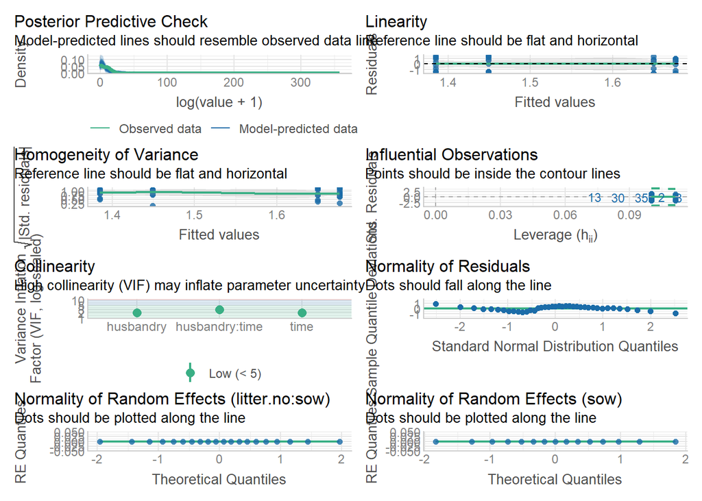

```r
performance::check_model(mod.prot)
```

## Emmeans & Effect sizes

### Husbandry

Emmeans:

```r
emm <- emmeans(mod.prot,
        pairwise ~ husbandry,
        data    = dat.l |>
          dplyr::filter(parameter == "proteolysis") |>
          droplevels() |>
          drop_na(value),
        adjust  = "tukey",
        lmer.df = "satterthwaite",
        type    = "response")
```

```
NOTE: Results may be misleading due to involvement in interactions
```

```r
emm
```

```
$emmeans
 husbandry    response   SE df lower.CL upper.CL
 conventional     3.56 1.25 35     1.62     6.94
 ecological       3.77 1.27 35     1.78     7.18

Results are averaged over the levels of: time
Degrees-of-freedom method: satterthwaite
Confidence level used: 0.95
Intervals are back-transformed from the log(mu + 1) scale

$contrasts
 contrast                  estimate    SE df t.ratio p.value
 conventional - ecological  -0.0452 0.381 35  -0.119  0.9063

Results are averaged over the levels of: time
Note: contrasts are still on the log(mu + 1) scale. Consider using
      regrid() if you want contrasts of back-transformed estimates.
Degrees-of-freedom method: satterthwaite
```

Effect sizes:

```r
eff_size(emm,
         sigma = sigma(mod.prot),
         edf = df.residual(mod.prot))
```

```
Since 'object' is a list, we are using the contrasts already present.
```

```
 contrast                    estimate    SE df lower.CL upper.CL
 (conventional - ecological)   -0.038 0.321 35   -0.689    0.613

Results are averaged over the levels of: time
sigma used for effect sizes: 1.189
Degrees-of-freedom method: inherited from satterthwaite when re-gridding
Confidence level used: 0.95
```

### Time point

Emmeans:

```r
emm <- emmeans(mod.prot,
        pairwise ~ time,
        data    = dat.l |>
          dplyr::filter(parameter == "proteolysis") |>
          droplevels() |>
          drop_na(value),
        adjust  = "tukey",
        lmer.df = "satterthwaite",
        type    = "response")
```

```
NOTE: Results may be misleading due to involvement in interactions
```

```r
emm
```

```
$emmeans
 time   response   SE df lower.CL upper.CL
 105dpc     3.71 1.29 35     1.70     7.20
 8dpp       3.62 1.23 35     1.69     6.93

Results are averaged over the levels of: husbandry
Degrees-of-freedom method: satterthwaite
Confidence level used: 0.95
Intervals are back-transformed from the log(mu + 1) scale

$contrasts
 contrast      estimate    SE df t.ratio p.value
 105dpc - 8dpp   0.0189 0.381 35   0.050  0.9608

Results are averaged over the levels of: husbandry
Note: contrasts are still on the log(mu + 1) scale. Consider using
      regrid() if you want contrasts of back-transformed estimates.
Degrees-of-freedom method: satterthwaite
```

Effect sizes:

```r
eff_size(emm,
         sigma = sigma(mod.prot),
         edf = df.residual(mod.prot))
```

```
Since 'object' is a list, we are using the contrasts already present.
```

```
 contrast        estimate    SE df lower.CL upper.CL
 (105dpc - 8dpp)   0.0159 0.321 35   -0.635    0.667

Results are averaged over the levels of: husbandry
sigma used for effect sizes: 1.189
Degrees-of-freedom method: inherited from satterthwaite when re-gridding
Confidence level used: 0.95
```

### Husbandry:Time point

Emmeans:

```r
emm.prot_ht <- emmeans(mod.prot,
                       pairwise ~ husbandry|time,
                       data    = dat.l |>
                         dplyr::filter(parameter == "proteolysis") |>
                         droplevels() |>
                         drop_na(value),
                       adjust  = "tukey",
                       lmer.df = "satterthwaite",
                       type    = "response")

emm.prot_ht
```

```
$emmeans
time = 105dpc:
 husbandry    response   SE df lower.CL upper.CL
 conventional     4.21 2.06 35    1.328    10.64
 ecological       3.26 1.60 35    0.985     8.14

time = 8dpp:
 husbandry    response   SE df lower.CL upper.CL
 conventional     2.99 1.50 35    0.862     7.57
 ecological       4.34 2.01 35    1.491    10.46

Degrees-of-freedom method: satterthwaite
Confidence level used: 0.95
Intervals are back-transformed from the log(mu + 1) scale

$contrasts
time = 105dpc:
 contrast                  estimate    SE df t.ratio p.value
 conventional - ecological    0.201 0.546 35   0.367  0.7155

time = 8dpp:
 contrast                  estimate    SE df t.ratio p.value
 conventional - ecological   -0.291 0.532 35  -0.547  0.5875

Note: contrasts are still on the log(mu + 1) scale. Consider using
      regrid() if you want contrasts of back-transformed estimates.
Degrees-of-freedom method: satterthwaite
```

Effect sizes:

```r
eff_size(emm.prot_ht,
         sigma = sigma(mod.prot),
         edf = df.residual(mod.prot))
```

```
Since 'object' is a list, we are using the contrasts already present.
```

```
time = 105dpc:
 contrast                    estimate    SE df lower.CL upper.CL
 (conventional - ecological)    0.169 0.460 35   -0.765    1.103

time = 8dpp:
 contrast                    estimate    SE df lower.CL upper.CL
 (conventional - ecological)   -0.245 0.448 35   -1.155    0.665

sigma used for effect sizes: 1.189
Degrees-of-freedom method: inherited from satterthwaite when re-gridding
Confidence level used: 0.95
```

### Time point:Husbandry

Emmeans:

```r
emm.prot_th <- emmeans(mod.prot,
                       pairwise ~ time|husbandry,
                       data    = dat.l |>
                         dplyr::filter(parameter == "proteolysis") |>
                         droplevels() |>
                         drop_na(value),
                       adjust  = "tukey",
                       lmer.df = "satterthwaite",
                       type    = "response")

emm.prot_th
```

```
$emmeans
husbandry = conventional:
 time   response   SE df lower.CL upper.CL
 105dpc     4.21 2.06 35    1.328    10.64
 8dpp       2.99 1.50 35    0.862     7.57

husbandry = ecological:
 time   response   SE df lower.CL upper.CL
 105dpc     3.26 1.60 35    0.985     8.14
 8dpp       4.34 2.01 35    1.491    10.46

Degrees-of-freedom method: satterthwaite
Confidence level used: 0.95
Intervals are back-transformed from the log(mu + 1) scale

$contrasts
husbandry = conventional:
 contrast      estimate    SE df t.ratio p.value
 105dpc - 8dpp    0.265 0.546 35   0.485  0.6309

husbandry = ecological:
 contrast      estimate    SE df t.ratio p.value
 105dpc - 8dpp   -0.227 0.532 35  -0.427  0.6720

Note: contrasts are still on the log(mu + 1) scale. Consider using
      regrid() if you want contrasts of back-transformed estimates.
Degrees-of-freedom method: satterthwaite
```

Effect sizes:

```r
eff_size(emm.prot_th,
         sigma = sigma(mod.prot),
         edf = df.residual(mod.prot))
```

```
Since 'object' is a list, we are using the contrasts already present.
```

```
husbandry = conventional:
 contrast        estimate    SE df lower.CL upper.CL
 (105dpc - 8dpp)    0.223 0.460 35   -0.712    1.157

husbandry = ecological:
 contrast        estimate    SE df lower.CL upper.CL
 (105dpc - 8dpp)   -0.191 0.448 35   -1.100    0.718

sigma used for effect sizes: 1.189
Degrees-of-freedom method: inherited from satterthwaite when re-gridding
Confidence level used: 0.95
```

## Plot

```r
plot.prot <- dat.l  |>
  dplyr::filter(parameter == "proteolysis") |>
  droplevels() |>
  drop_na(value) |>
  # plot
  mutate(jit = jitter(as.numeric(time), 0.3)) |>
  ggplot(aes(y   = value)) +
  geom_boxplot(aes(x   = time,
                   fill = husbandry),
               col = "black",
               outlier.shape = NA, width = 0.5) +
  geom_jitter(aes(x   = time,
                  fill = husbandry),
              col = "black",
              position = position_jitterdodge(jitter.width  = 0.15,
                                              dodge.width   = 0.5),
              size = 2, alpha = 0.7,
              show.legend = FALSE) +
  scale_fill_manual(labels = c("Conventional",
                               "Ecological"),
                    values = c("#FFA040", "#008000")) +
  scale_y_continuous(lim = c(0, 21),
                     breaks = seq(0, 21, 5),
                     minor_breaks = seq(0, 21, by = 1) ) +
  scale_x_discrete(labels= c("105dpc", "8dpp")) +
  labs(x = "",
       y = "Proteolytic activity (serum) [%]",
       fill = "Husbandry") +
  my_theme +
  theme(legend.position = "top") +
  guides(y = guide_axis(minor.ticks = TRUE),
         fill = guide_legend(override.aes = list(linetype = 0, size  = 5)))
```

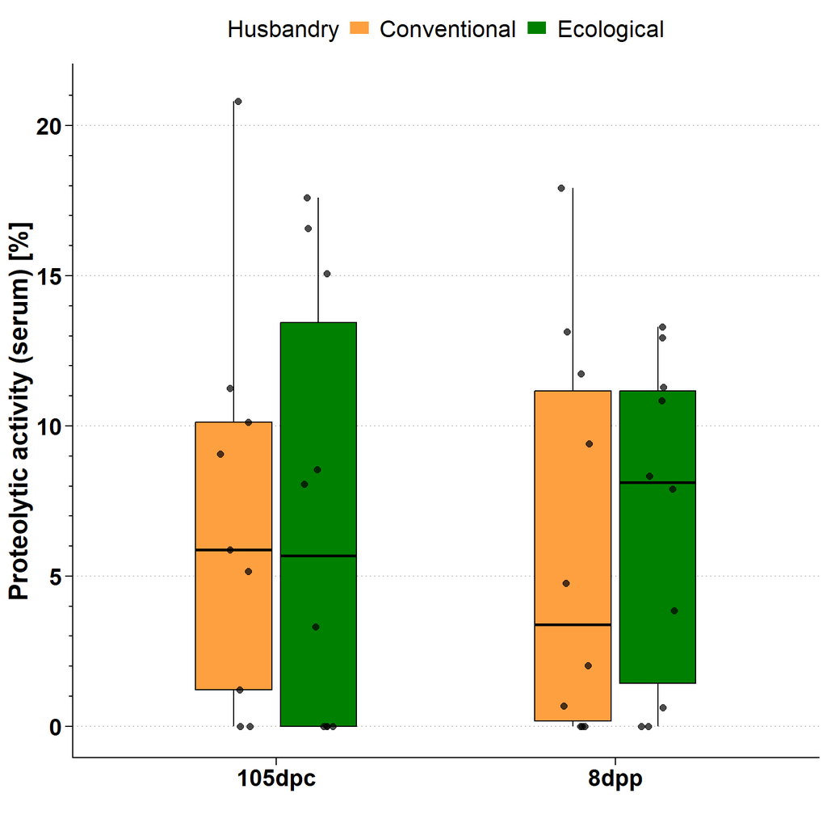

```r
plot.prot
```

# Calcium (serum)

## Model

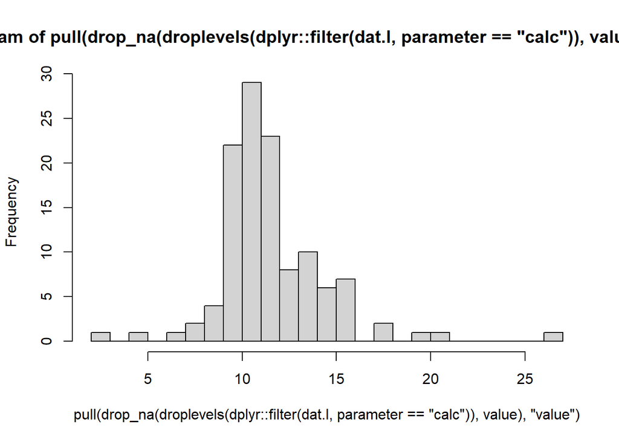

```r
hist(dat.l |>
       dplyr::filter(parameter == "calc") |>
       droplevels() |>
       drop_na(value) |>
       pull("value"),
     breaks = 30)
```

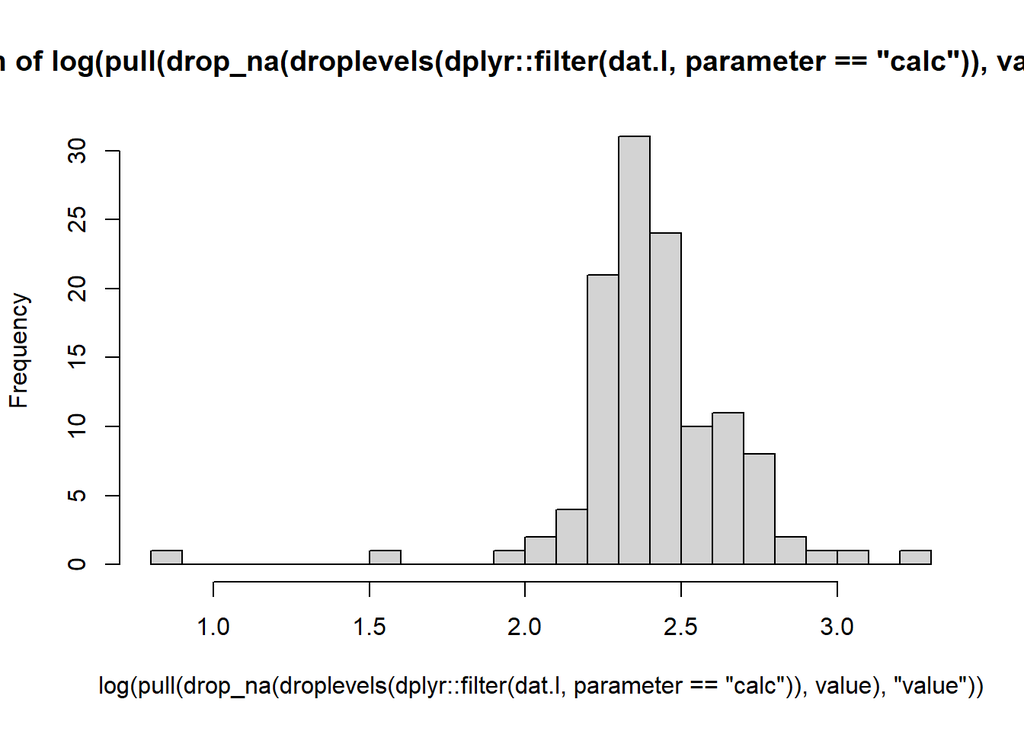

```r
hist(log(dat.l |>
         dplyr::filter(parameter == "calc") |>
         droplevels() |>
         drop_na(value) |>
         pull("value")),
     breaks = 30)
```

Singularity issues if nested structure defined like `(1 | sow/litter.no)`.

```r
mod.calc <- lmerTest::lmer(log(value) ~
                               husbandry +
                               time +
                               # interaction term
                               husbandry : time +
                               # random intercept for sows and for each litter within sow
                               (1 | sow/litter.no),
                             data    = dat.l |>
                               dplyr::filter(parameter == "calc") |>
                               dplyr::filter(time != "30dpc") |>
                               droplevels() |>
                               drop_na(value),
                             REML    = TRUE,
                             control = contr)
```

```
boundary (singular) fit: see help('isSingular')
```

```r
summary(mod.calc)
```

```
Linear mixed model fit by REML. t-tests use Satterthwaite's method [
lmerModLmerTest]
Formula: log(value) ~ husbandry + time + husbandry:time + (1 | sow/litter.no)
   Data: drop_na(droplevels(dplyr::filter(dplyr::filter(dat.l, parameter ==
    "calc"), time != "30dpc")), value)
Control: contr

REML criterion at convergence: 4.1

Scaled residuals:
    Min      1Q  Median      3Q     Max
-5.9530 -0.3184  0.0786  0.3944  1.6808

Random effects:
 Groups        Name        Variance  Std.Dev.
 litter.no:sow (Intercept) 6.379e-18 2.526e-09
 sow           (Intercept) 3.982e-02 1.995e-01
 Residual                  3.860e-02 1.965e-01
Number of obs: 80, groups:  litter.no:sow, 40; sow, 15

Fixed effects:
                             Estimate Std. Error       df t value Pr(>|t|)
(Intercept)                   2.42516    0.08737 15.46761  27.756 1.29e-14 ***
husbandryecological          -0.08834    0.12130 16.18553  -0.728    0.477
time8dpp                     -0.02237    0.06213 62.42643  -0.360    0.720
husbandryecological:time8dpp  0.10889    0.08786 62.42643   1.239    0.220
---
Signif. codes:  0 '***' 0.001 '**' 0.01 '*' 0.05 '.' 0.1 ' ' 1

Correlation of Fixed Effects:
            (Intr) hsbndr tm8dpp
hsbndryclgc -0.720
time8dpp    -0.356  0.256
hsbndrycl:8  0.251 -0.362 -0.707
optimizer (bobyqa) convergence code: 0 (OK)
boundary (singular) fit: see help('isSingular')
```

```r
round(drop1(mod.calc, test = 'Chisq'), 3)
```

```
Single term deletions using Satterthwaite's method:

Model:
log(value) ~ husbandry + time + husbandry:time + (1 | sow/litter.no)
               Sum Sq Mean Sq NumDF  DenDF F value Pr(>F)
husbandry:time  0.059   0.059     1 62.426   1.536   0.22
```

Without significant interactions, choose `type = 2`. With significant interactions, choose `type = 3`.

```r
car::Anova(mod.calc,
           test.statistic = "Chisq",
           type = 2)
```

```
Analysis of Deviance Table (Type II Wald chisquare tests)

Response: log(value)
                Chisq Df Pr(>Chisq)
husbandry      0.0899  1     0.7644
time           0.5333  1     0.4652
husbandry:time 1.5360  1     0.2152
```

```r
car::Anova(mod.calc,
           test.statistic = "F",
           type = 2)
```

```
Analysis of Deviance Table (Type II Wald F tests with Kenward-Roger df)

Response: log(value)
                    F Df Df.res Pr(>F)
husbandry      0.0897  1 12.849 0.7694
time           0.5333  1 38.000 0.4697
husbandry:time 1.5360  1 38.000 0.2228
```

## Model diagnostics

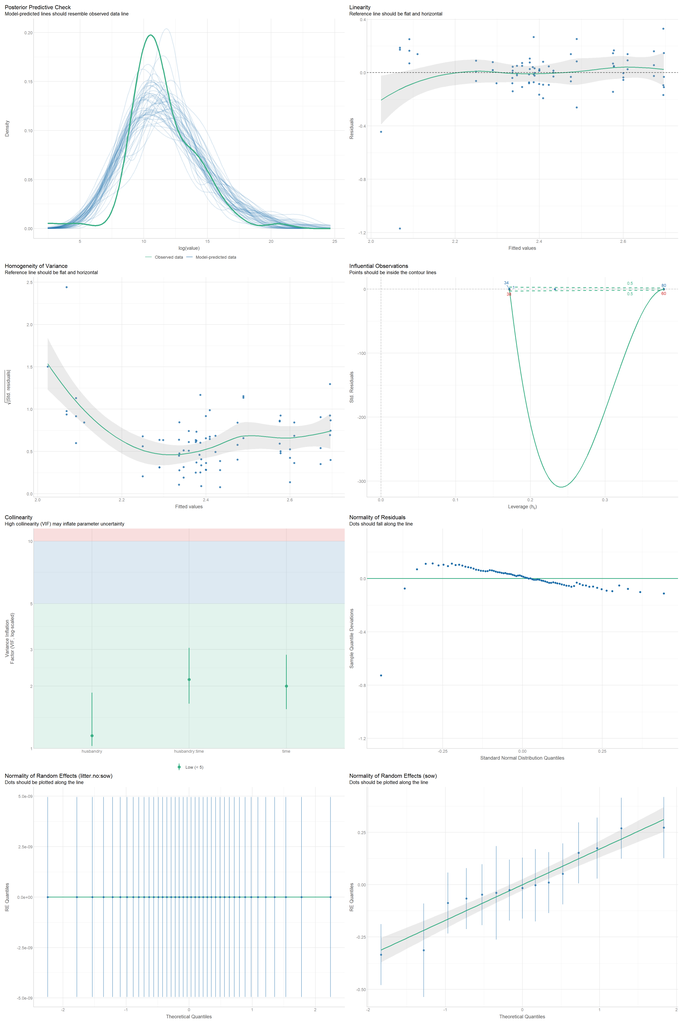

```r
performance::check_model(mod.calc)
```

## Emmeans & Effect sizes

### Husbandry

Emmeans:

```r
emm <- emmeans(mod.calc,
        pairwise ~ husbandry,
        data    = dat.l |>
          dplyr::filter(parameter == "calc") |>
          dplyr::filter(time != "30dpc") |>
          droplevels() |>
          drop_na(value),
        adjust  = "tukey",
        lmer.df = "satterthwaite",
        type    = "response")
```

```
NOTE: Results may be misleading due to involvement in interactions
```

```r
emm
```

```
$emmeans
 husbandry    response    SE   df lower.CL upper.CL
 conventional     11.2 0.913 11.8     9.35     13.4
 ecological       10.8 0.845 12.7     9.12     12.8

Results are averaged over the levels of: time
Degrees-of-freedom method: satterthwaite
Confidence level used: 0.95
Intervals are back-transformed from the log scale

$contrasts
 contrast                  ratio    SE   df null t.ratio p.value
 conventional / ecological  1.03 0.117 12.2    1   0.300  0.7694

Results are averaged over the levels of: time
Degrees-of-freedom method: satterthwaite
Tests are performed on the log scale
```

Effect sizes:

```r
eff_size(emm,
         sigma = sigma(mod.calc),
         edf = df.residual(mod.calc))
```

```
Since 'object' is a list, we are using the contrasts already present.
```

```
 contrast                    estimate    SE   df lower.CL upper.CL
 (conventional - ecological)    0.173 0.576 12.2    -1.08     1.42

Results are averaged over the levels of: time
sigma used for effect sizes: 0.1965
Degrees-of-freedom method: inherited from satterthwaite when re-gridding
Confidence level used: 0.95
```

### Time point

Emmeans:

```r
emm <- emmeans(mod.calc,
        pairwise ~ time,
        data    = dat.l |>
          dplyr::filter(parameter == "calc") |>
          dplyr::filter(time != "30dpc") |>
          droplevels() |>
          drop_na(value),
        adjust  = "tukey",
        lmer.df = "satterthwaite",
        type    = "response")
```

```
NOTE: Results may be misleading due to involvement in interactions
```

```r
emm
```

```
$emmeans
 time   response    SE   df lower.CL upper.CL
 105dpc     10.8 0.656 16.2     9.51     12.3
 8dpp       11.2 0.677 16.2     9.82     12.7

Results are averaged over the levels of: husbandry
Degrees-of-freedom method: satterthwaite
Confidence level used: 0.95
Intervals are back-transformed from the log scale

$contrasts
 contrast      ratio     SE   df null t.ratio p.value
 105dpc / 8dpp 0.968 0.0425 62.4    1  -0.730  0.4680

Results are averaged over the levels of: husbandry
Degrees-of-freedom method: satterthwaite
Tests are performed on the log scale
```

Effect sizes:

```r
eff_size(emm,
         sigma = sigma(mod.calc),
         edf = df.residual(mod.calc))
```

```
Since 'object' is a list, we are using the contrasts already present.
```

```
 contrast        estimate    SE   df lower.CL upper.CL
 (105dpc - 8dpp)   -0.163 0.224 62.4   -0.611    0.284

Results are averaged over the levels of: husbandry
sigma used for effect sizes: 0.1965
Degrees-of-freedom method: inherited from satterthwaite when re-gridding
Confidence level used: 0.95
```

### Husbandry:Time point

Emmeans:

```r
emm.calc_ht <- emmeans(mod.calc,
                       pairwise ~ husbandry|time,
                       data    = dat.l |>
                         dplyr::filter(parameter == "calc") |>
                         dplyr::filter(time != "30dpc") |>
                         droplevels() |>
                         drop_na(value),
                       adjust  = "tukey",
                       lmer.df = "satterthwaite",
                       type    = "response")

emm.calc_ht
```

```
$emmeans
time = 105dpc:
 husbandry    response    SE   df lower.CL upper.CL
 conventional     11.3 0.988 15.5     9.39     13.6
 ecological       10.3 0.871 17.0     8.67     12.4

time = 8dpp:
 husbandry    response    SE   df lower.CL upper.CL
 conventional     11.1 0.966 15.5     9.18     13.3
 ecological       11.3 0.949 17.0     9.45     13.5

Degrees-of-freedom method: satterthwaite
Confidence level used: 0.95
Intervals are back-transformed from the log scale

$contrasts
time = 105dpc:
 contrast                  ratio    SE   df null t.ratio p.value
 conventional / ecological  1.09 0.133 16.2    1   0.728  0.4768

time = 8dpp:
 contrast                  ratio    SE   df null t.ratio p.value
 conventional / ecological  0.98 0.119 16.2    1  -0.169  0.8675

Degrees-of-freedom method: satterthwaite
Tests are performed on the log scale
```

Effect sizes:

```r
eff_size(emm.calc_ht,
         sigma = sigma(mod.calc),
         edf = df.residual(mod.calc))
```

```
Since 'object' is a list, we are using the contrasts already present.
```

```
time = 105dpc:
 contrast                    estimate    SE   df lower.CL upper.CL
 (conventional - ecological)    0.450 0.619 16.2    -0.86     1.76

time = 8dpp:
 contrast                    estimate    SE   df lower.CL upper.CL
 (conventional - ecological)   -0.105 0.617 16.2    -1.41     1.20

sigma used for effect sizes: 0.1965
Degrees-of-freedom method: inherited from satterthwaite when re-gridding
Confidence level used: 0.95
```

### Time point:Husbandry

Emmeans:

```r
emm.calc_th <- emmeans(mod.calc,
                       pairwise ~ time|husbandry,
                       data    = dat.l |>
                         dplyr::filter(parameter == "calc") |>
                         dplyr::filter(time != "30dpc") |>
                         droplevels() |>
                         drop_na(value),
                       adjust  = "tukey",
                       lmer.df = "satterthwaite",
                       type    = "response")

emm.calc_th
```

```
$emmeans
husbandry = conventional:
 time   response    SE   df lower.CL upper.CL
 105dpc     11.3 0.988 15.5     9.39     13.6
 8dpp       11.1 0.966 15.5     9.18     13.3

husbandry = ecological:
 time   response    SE   df lower.CL upper.CL
 105dpc     10.3 0.871 17.0     8.67     12.4
 8dpp       11.3 0.949 17.0     9.45     13.5

Degrees-of-freedom method: satterthwaite
Confidence level used: 0.95
Intervals are back-transformed from the log scale

$contrasts
husbandry = conventional:
 contrast      ratio     SE   df null t.ratio p.value
 105dpc / 8dpp 1.023 0.0635 62.4    1   0.360  0.7201

husbandry = ecological:
 contrast      ratio     SE   df null t.ratio p.value
 105dpc / 8dpp 0.917 0.0570 62.4    1  -1.393  0.1686

Degrees-of-freedom method: satterthwaite
Tests are performed on the log scale
```

Effect sizes:

```r
eff_size(emm.calc_th,
         sigma = sigma(mod.calc),
         edf = df.residual(mod.calc))
```

```
Since 'object' is a list, we are using the contrasts already present.
```

```
husbandry = conventional:
 contrast        estimate    SE   df lower.CL upper.CL
 (105dpc - 8dpp)    0.114 0.316 62.4   -0.518    0.746

husbandry = ecological:
 contrast        estimate    SE   df lower.CL upper.CL
 (105dpc - 8dpp)   -0.440 0.318 62.4   -1.077    0.196

sigma used for effect sizes: 0.1965
Degrees-of-freedom method: inherited from satterthwaite when re-gridding
Confidence level used: 0.95
```

## Plot

```r
plot.calc <- dat.l  |>
  dplyr::filter(parameter == "calc") |>
  dplyr::filter(time != "30dpc") |>
  droplevels() |>
  drop_na(value) |>
  # plot
  mutate(jit = jitter(as.numeric(time), 0.3)) |>
  ggplot(aes(y   = value)) +
  geom_boxplot(aes(x   = time,
                   fill = husbandry),
               col = "black",
               outlier.shape = NA, width = 0.5) +
  geom_jitter(aes(x   = time,
                  fill = husbandry),
              col = "black",
              position = position_jitterdodge(jitter.width  = 0.15,
                                              dodge.width   = 0.5),
              size = 2, alpha = 0.7,
              show.legend = FALSE) +
  scale_fill_manual(labels = c("Conventional",
                               "Ecological"),
                    values = c("#FFA040", "#008000")) +
  scale_y_continuous(lim = c(0, 21),
                     breaks = seq(0, 20, 5),
                     minor_breaks = seq(0, 20, by = 2) ) +
  scale_x_discrete(labels= c("105dpc", "8dpp")) +
  labs(x = "",
       y = "Calcium (serum) [mg/dl]",
       fill = "Husbandry") +
  my_theme +
  theme(legend.position = "top") +
  guides(y = guide_axis(minor.ticks = TRUE),
         fill = guide_legend(override.aes = list(linetype = 0, size  = 5)))
```

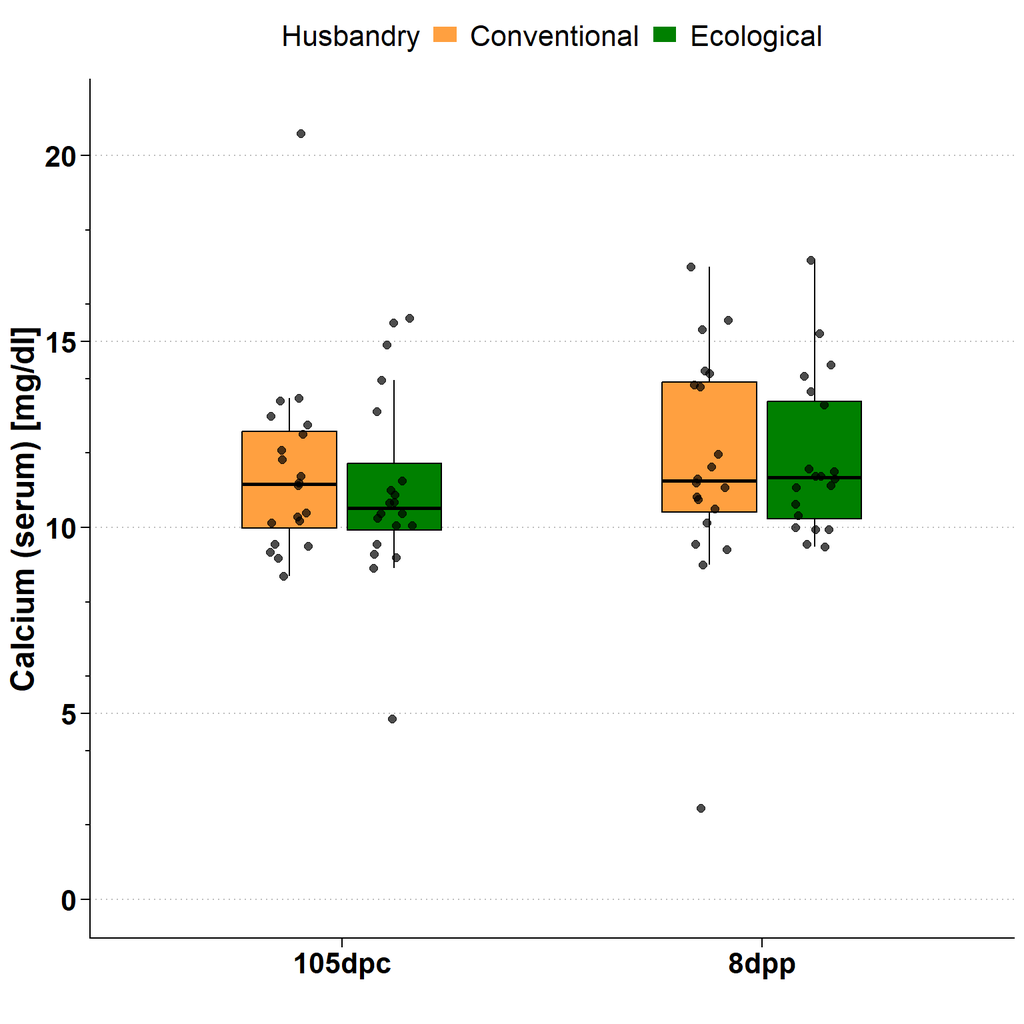

```r
plot.calc
```

# How to cite R

“All analyses were performed using R Statistical Software (version 4.4.2; R Core Team 2024)”.

Reference: R Core Team (2024). R: A language and environment for statistical computing. R Foundation for Statistical Computing, Vienna, Austria. URL https://www.R-project.org/.

```r
citation()
```

```
  R Core Team (2024). _R: A Language and Environment for Statistical
  Computing_. R Foundation for Statistical Computing, Vienna, Austria.
  <https://www.R-project.org/>.

Ein BibTeX-Eintrag für LaTeX-Benutzer ist

  @Manual{,
    title = {R: A Language and Environment for Statistical Computing},
    author = {{R Core Team}},
    organization = {R Foundation for Statistical Computing},
    address = {Vienna, Austria},
    year = {2024},
    url = {https://www.R-project.org/},
  }

We have invested a lot of time and effort in creating R, please cite it
when using it for data analysis. See also 'citation("pkgname")' for
citing R packages.
```

```r
version$version.string
```

```
[1] "R version 4.4.2 (2024-10-31 ucrt)"
```

```r
citation("tidyverse")
```

```
Um Paket 'tidyverse' in Publikationen zu zitieren, nutzen Sie bitte:

  Wickham H, Averick M, Bryan J, Chang W, McGowan LD, François R,
  Grolemund G, Hayes A, Henry L, Hester J, Kuhn M, Pedersen TL, Miller
  E, Bache SM, Müller K, Ooms J, Robinson D, Seidel DP, Spinu V,
  Takahashi K, Vaughan D, Wilke C, Woo K, Yutani H (2019). "Welcome to
  the tidyverse." _Journal of Open Source Software_, *4*(43), 1686.
  doi:10.21105/joss.01686 <https://doi.org/10.21105/joss.01686>.

Ein BibTeX-Eintrag für LaTeX-Benutzer ist

  @Article{,
    title = {Welcome to the {tidyverse}},
    author = {Hadley Wickham and Mara Averick and Jennifer Bryan and Winston Chang and Lucy D'Agostino McGowan and Romain François and Garrett Grolemund and Alex Hayes and Lionel Henry and Jim Hester and Max Kuhn and Thomas Lin Pedersen and Evan Miller and Stephan Milton Bache and Kirill Müller and …
    year = {2019},
    journal = {Journal of Open Source Software},
    volume = {4},
    number = {43},
    pages = {1686},
    doi = {10.21105/joss.01686},
  }
```

```r
citation("kableExtra")
```

```
Um Paket 'kableExtra' in Publikationen zu zitieren, nutzen Sie bitte:

  Zhu H (2024). _kableExtra: Construct Complex Table with 'kable' and
  Pipe Syntax_. R package version 1.4.0,
  <https://CRAN.R-project.org/package=kableExtra>.

Ein BibTeX-Eintrag für LaTeX-Benutzer ist

  @Manual{,
    title = {kableExtra: Construct Complex Table with 'kable' and Pipe Syntax},
    author = {Hao Zhu},
    year = {2024},
    note = {R package version 1.4.0},
    url = {https://CRAN.R-project.org/package=kableExtra},
  }
```

```r
citation("patchwork")
```

```
Um Paket 'patchwork' in Publikationen zu zitieren, nutzen Sie bitte:

  Pedersen T (2025). _patchwork: The Composer of Plots_. R package
  version 1.3.2, <https://CRAN.R-project.org/package=patchwork>.

Ein BibTeX-Eintrag für LaTeX-Benutzer ist

  @Manual{,
    title = {patchwork: The Composer of Plots},
    author = {Thomas Lin Pedersen},
    year = {2025},
    note = {R package version 1.3.2},
    url = {https://CRAN.R-project.org/package=patchwork},
  }
```

```r
citation("lmerTest")
```

```
  Kuznetsova A, Brockhoff PB, Christensen RHB (2017). "lmerTest
  Package: Tests in Linear Mixed Effects Models." _Journal of
  Statistical Software_, *82*(13), 1-26. doi:10.18637/jss.v082.i13
  <https://doi.org/10.18637/jss.v082.i13>.

Ein BibTeX-Eintrag für LaTeX-Benutzer ist

  @Article{,
    title = {{lmerTest} Package: Tests in Linear Mixed Effects Models},
    author = {Alexandra Kuznetsova and Per B. Brockhoff and Rune H. B. Christensen},
    journal = {Journal of Statistical Software},
    year = {2017},
    volume = {82},
    number = {13},
    pages = {1--26},
    doi = {10.18637/jss.v082.i13},
  }
```

```r
citation("car")
```

```
  Fox J, Weisberg S (2019). _An R Companion to Applied Regression_,
  Third edition. Sage, Thousand Oaks CA.
  <https://www.john-fox.ca/Companion/>.

Ein BibTeX-Eintrag für LaTeX-Benutzer ist

  @Book{,
    title = {An {R} Companion to Applied Regression},
    edition = {Third},
    author = {John Fox and Sanford Weisberg},
    year = {2019},
    publisher = {Sage},
    address = {Thousand Oaks {CA}},
    url = {https://www.john-fox.ca/Companion/},
  }
```

```r
citation("emmeans")
```

```
Um Paket 'emmeans' in Publikationen zu zitieren, nutzen Sie bitte:

  Lenth R (2024). _emmeans: Estimated Marginal Means, aka Least-Squares
  Means_. R package version 1.10.6,
  <https://CRAN.R-project.org/package=emmeans>.

Ein BibTeX-Eintrag für LaTeX-Benutzer ist

  @Manual{,
    title = {emmeans: Estimated Marginal Means, aka Least-Squares Means},
    author = {Russell V. Lenth},
    year = {2024},
    note = {R package version 1.10.6},
    url = {https://CRAN.R-project.org/package=emmeans},
  }
```

```r
citation("performance")
```

```
Um Paket 'performance' in Publikationen zu zitieren, nutzen Sie bitte:

  Lüdecke et al., (2021). performance: An R Package for Assessment,
  Comparison and Testing of Statistical Models. Journal of Open Source
  Software, 6(60), 3139. https://doi.org/10.21105/joss.03139

Ein BibTeX-Eintrag für LaTeX-Benutzer ist

  @Article{,
    title = {{performance}: An {R} Package for Assessment, Comparison and Testing of Statistical Models},
    author = {Daniel Lüdecke and Mattan S. Ben-Shachar and Indrajeet Patil and Philip Waggoner and Dominique Makowski},
    year = {2021},
    journal = {Journal of Open Source Software},
    volume = {6},
    number = {60},
    pages = {3139},
    doi = {10.21105/joss.03139},
  }
```

```r
citation("Hmisc")
```

```
Um Paket 'Hmisc' in Publikationen zu zitieren, nutzen Sie bitte:

  Harrell Jr F (2025). _Hmisc: Harrell Miscellaneous_. R package
  version 5.2-3, <https://CRAN.R-project.org/package=Hmisc>.

Ein BibTeX-Eintrag für LaTeX-Benutzer ist

  @Manual{,
    title = {Hmisc: Harrell Miscellaneous},
    author = {Frank E {Harrell Jr}},
    year = {2025},
    note = {R package version 5.2-3},
    url = {https://CRAN.R-project.org/package=Hmisc},
  }
```

```r
citation("viridis")
```

```
  Simon Garnier, Noam Ross, Robert Rudis, Antônio P. Camargo, Marco
  Sciaini, and Cédric Scherer (2024). viridis(Lite) -
  Colorblind-Friendly Color Maps for R. viridis package version 0.6.5.

Ein BibTeX-Eintrag für LaTeX-Benutzer ist

  @Manual{,
    title = {{viridis(Lite)} - Colorblind-Friendly Color Maps for R},
    author = {{Garnier} and {Simon} and {Ross} and {Noam} and {Rudis} and {Robert} and {Camargo} and Antônio Pedro and {Sciaini} and {Marco} and {Scherer} and {Cédric}},
    year = {2024},
    note = {viridis package version 0.6.5},
    url = {https://sjmgarnier.github.io/viridis/},
    doi = {10.5281/zenodo.4679423},
  }
```